# Assignment5

Manpreet Kaur

2025-11-23

```r
library(dplyr)
```

```r
library(ggplot2)
library(cluster)   # agnes(), silhouette()
```

# 1. Introduction

The goal of this assignment is to apply **hierarchical clustering** to a data set of breakfast cereals and to use the resulting clusters to support a practical decision: choosing healthy cereals for elementary school cafeterias.

The `Cereals.csv` file contains information on **77 breakfast cereals**, including:

- Nutritional variables (calories, protein, fat, sodium, fiber, carbohydrates, sugars, potassium, vitamins),
- Presentation variables (shelf, serving size),
- Consumer ratings.

In this report I:

1. Preprocess the data by removing cereals with missing values.
2. Apply hierarchical clustering using **Euclidean distance on normalized measurements**.
3. Use `agnes()` to compare four linkage methods: **single**, **complete**, **average**, and **Ward’s method**.
4. Select the “best” linkage method and choose a reasonable number of clusters.
5. Describe the **structure** and **stability** of the clusters, using a partition-based stability check.
6. Identify a cluster of **“healthy cereals”** for elementary schools and discuss how normalization should be treated in that context.

The emphasis is both on correct implementation and on clear interpretation of the results.

# 2. Data preparation

## 2.1 Load the data and inspect structure

```r
cereals <- read.csv("Cereals.csv")

str(cereals)
```

```
## 'data.frame':    77 obs. of  16 variables:
##  $ name    : chr  "100%_Bran" "100%_Natural_Bran" "All-Bran" "All-Bran_with_Extra_Fiber" ...
##  $ mfr     : chr  "N" "Q" "K" "K" ...
##  $ type    : chr  "C" "C" "C" "C" ...
##  $ calories: int  70 120 70 50 110 110 110 130 90 90 ...
##  $ protein : int  4 3 4 4 2 2 2 3 2 3 ...
##  $ fat     : int  1 5 1 0 2 2 0 2 1 0 ...
##  $ sodium  : int  130 15 260 140 200 180 125 210 200 210 ...
##  $ fiber   : num  10 2 9 14 1 1.5 1 2 4 5 ...
##  $ carbo   : num  5 8 7 8 14 10.5 11 18 15 13 ...
##  $ sugars  : int  6 8 5 0 8 10 14 8 6 5 ...
##  $ potass  : int  280 135 320 330 NA 70 30 100 125 190 ...
##  $ vitamins: int  25 0 25 25 25 25 25 25 25 25 ...
##  $ shelf   : int  3 3 3 3 3 1 2 3 1 3 ...
##  $ weight  : num  1 1 1 1 1 1 1 1.33 1 1 ...
##  $ cups    : num  0.33 1 0.33 0.5 0.75 0.75 1 0.75 0.67 0.67 ...
##  $ rating  : num  68.4 34 59.4 93.7 34.4 ...
```

```r
summary(cereals)
```

```
##      name               mfr                type              calories
##  Length:77          Length:77          Length:77          Min.   : 50.0
##  Class :character   Class :character   Class :character   1st Qu.:100.0
##  Mode  :character   Mode  :character   Mode  :character   Median :110.0
##                                                           Mean   :106.9
##                                                           3rd Qu.:110.0
##                                                           Max.   :160.0
##
##     protein           fat            sodium          fiber
##  Min.   :1.000   Min.   :0.000   Min.   :  0.0   Min.   : 0.000
##  1st Qu.:2.000   1st Qu.:0.000   1st Qu.:130.0   1st Qu.: 1.000
##  Median :3.000   Median :1.000   Median :180.0   Median : 2.000
##  Mean   :2.545   Mean   :1.013   Mean   :159.7   Mean   : 2.152
##  3rd Qu.:3.000   3rd Qu.:2.000   3rd Qu.:210.0   3rd Qu.: 3.000
##  Max.   :6.000   Max.   :5.000   Max.   :320.0   Max.   :14.000
##
##      carbo          sugars           potass          vitamins
##  Min.   : 5.0   Min.   : 0.000   Min.   : 15.00   Min.   :  0.00
##  1st Qu.:12.0   1st Qu.: 3.000   1st Qu.: 42.50   1st Qu.: 25.00
##  Median :14.5   Median : 7.000   Median : 90.00   Median : 25.00
##  Mean   :14.8   Mean   : 7.026   Mean   : 98.67   Mean   : 28.25
##  3rd Qu.:17.0   3rd Qu.:11.000   3rd Qu.:120.00   3rd Qu.: 25.00
##  Max.   :23.0   Max.   :15.000   Max.   :330.00   Max.   :100.00
##  NA's   :1      NA's   :1        NA's   :2
##      shelf           weight          cups           rating
##  Min.   :1.000   Min.   :0.50   Min.   :0.250   Min.   :18.04
##  1st Qu.:1.000   1st Qu.:1.00   1st Qu.:0.670   1st Qu.:33.17
##  Median :2.000   Median :1.00   Median :0.750   Median :40.40
##  Mean   :2.208   Mean   :1.03   Mean   :0.821   Mean   :42.67
##  3rd Qu.:3.000   3rd Qu.:1.00   3rd Qu.:1.000   3rd Qu.:50.83
##  Max.   :3.000   Max.   :1.50   Max.   :1.500   Max.   :93.70
##
```

```r
nrow(cereals)
```

```
## [1] 77
```

The dataset contains information on each cereal, including its name, manufacturer, type, nutritional composition, and rating. Some variables are categorical (e.g., `mfr`, `type`, `name`), while most are numeric.

## 2.2 Remove cereals with missing values

The assignment instructs us to **remove cereals with missing values** before clustering. This ensures that the distance calculations and clustering steps are based on complete cases.

```r
cereals_clean <- na.omit(cereals)

nrow(cereals_clean)
```

```
## [1] 74
```

```r
sum(!complete.cases(cereals))
```

```
## [1] 3
```

The output shows how many cereals remain after dropping records with missing values. All further analysis is based on `cereals_clean`.

## 2.3 Select numeric variables and normalize

Hierarchical clustering will be based on **numeric variables** that describe the cereal’s measurable attributes. I exclude identifiers and purely categorical variables:

- Exclude: `name`, `mfr`, `type`.
- Include numeric fields:

  `calories`, `protein`, `fat`, `sodium`, `fiber`, `carbo`, `sugars`, `potass`, `vitamins`, `shelf`, `weight`, `cups`, `rating`.

```r
numeric_vars <- c(
  "calories", "protein", "fat", "sodium", "fiber",
  "carbo", "sugars", "potass", "vitamins",
  "shelf", "weight", "cups", "rating"
)

cereals_num <- cereals_clean[, numeric_vars]

summary(cereals_num)
```

```
##     calories      protein           fat        sodium          fiber
##  Min.   : 50   Min.   :1.000   Min.   :0   Min.   :  0.0   Min.   : 0.000
##  1st Qu.:100   1st Qu.:2.000   1st Qu.:0   1st Qu.:135.0   1st Qu.: 0.250
##  Median :110   Median :2.500   Median :1   Median :180.0   Median : 2.000
##  Mean   :107   Mean   :2.514   Mean   :1   Mean   :162.4   Mean   : 2.176
##  3rd Qu.:110   3rd Qu.:3.000   3rd Qu.:1   3rd Qu.:217.5   3rd Qu.: 3.000
##  Max.   :160   Max.   :6.000   Max.   :5   Max.   :320.0   Max.   :14.000
##      carbo           sugars           potass          vitamins
##  Min.   : 5.00   Min.   : 0.000   Min.   : 15.00   Min.   :  0.00
##  1st Qu.:12.00   1st Qu.: 3.000   1st Qu.: 41.25   1st Qu.: 25.00
##  Median :14.50   Median : 7.000   Median : 90.00   Median : 25.00
##  Mean   :14.73   Mean   : 7.108   Mean   : 98.51   Mean   : 29.05
##  3rd Qu.:17.00   3rd Qu.:11.000   3rd Qu.:120.00   3rd Qu.: 25.00
##  Max.   :23.00   Max.   :15.000   Max.   :330.00   Max.   :100.00
##      shelf           weight           cups            rating
##  Min.   :1.000   Min.   :0.500   Min.   :0.2500   Min.   :18.04
##  1st Qu.:1.250   1st Qu.:1.000   1st Qu.:0.6700   1st Qu.:32.45
##  Median :2.000   Median :1.000   Median :0.7500   Median :40.25
##  Mean   :2.216   Mean   :1.031   Mean   :0.8216   Mean   :42.37
##  3rd Qu.:3.000   3rd Qu.:1.000   3rd Qu.:1.0000   3rd Qu.:50.52
##  Max.   :3.000   Max.   :1.500   Max.   :1.5000   Max.   :93.70
```

These variables are on **very different scales** (for example, sodium vs. fiber vs. rating). To avoid variables with large numeric ranges dominating the distance computation, I **standardize** each numeric variable to mean 0 and standard deviation 1.

```r
cereals_scaled <- scale(cereals_num)

# Euclidean distance matrix on normalized data
dist_euclid <- dist(cereals_scaled, method = "euclidean")
```

Standardization ensures that each numeric variable contributes comparably to the Euclidean distance used in hierarchical clustering.

# 3. Hierarchical clustering with different linkage methods

## 3.1 Fit agnes models for four linkage methods

I apply `agnes()` with four linkage strategies on the same scaled data:

- Single linkage
- Complete linkage
- Average linkage
- Ward’s method

```r
agnes_single   <- agnes(cereals_scaled, method = "single")
agnes_complete <- agnes(cereals_scaled, method = "complete")
agnes_average  <- agnes(cereals_scaled, method = "average")
agnes_ward     <- agnes(cereals_scaled, method = "ward")
```

## 3.2 Agglomerative coefficients

The **agglomerative coefficient** (AC) measures the strength of the clustering structure (values closer to 1 indicate more coherent clusters).

```r
ac_table <- data.frame(
  method = c("single", "complete", "average", "ward"),
  agglomerative_coefficient = c(
    agnes_single$ac,
    agnes_complete$ac,
    agnes_average$ac,
    agnes_ward$ac
  )
)

ac_table
```

```
##     method agglomerative_coefficient
## 1   single                 0.6067859
## 2 complete                 0.8353712
## 3  average                 0.7766075
## 4     ward                 0.9046042
```

**Interpretation:**

- **Single linkage** typically has the lowest AC and tends to form long “chains,” which makes distinct clusters hard to interpret.
- **Complete** and **average linkage** generally produce more compact, well-separated clusters.
- **Ward’s method** often achieves a high AC because it explicitly minimizes within-cluster variance.

## 3.3 Dendrogram comparison

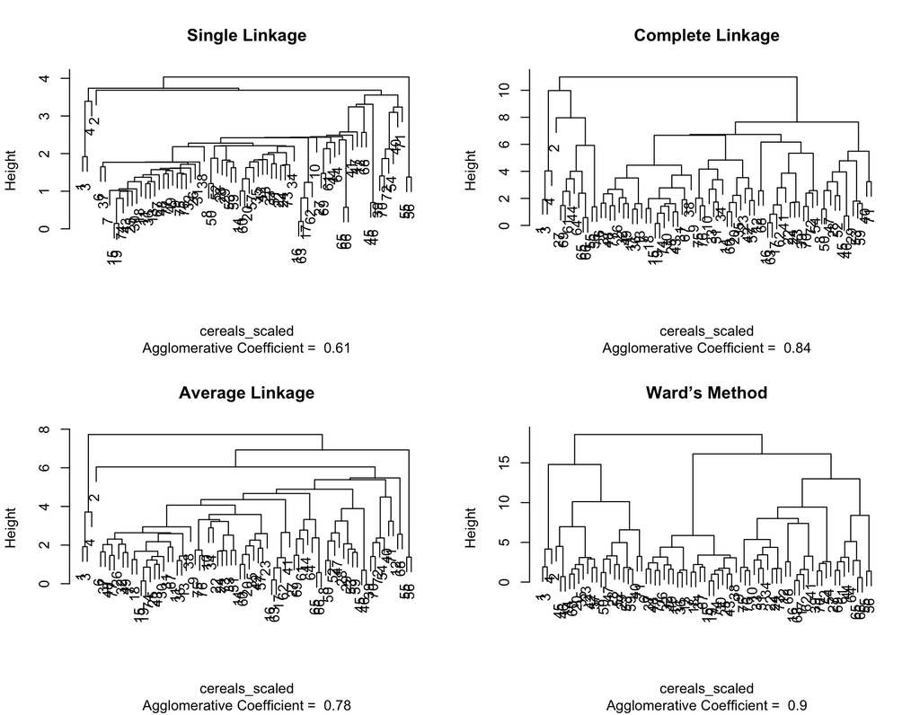

```r
par(mfrow = c(2, 2))

plot(agnes_single,   which.plots = 2, main = "Single Linkage")
plot(agnes_complete, which.plots = 2, main = "Complete Linkage")
plot(agnes_average,  which.plots = 2, main = "Average Linkage")
plot(agnes_ward,     which.plots = 2, main = "Ward’s Method")
```

```r
par(mfrow = c(1, 1))
```

**Visual impression:**

- The **single-linkage** dendrogram shows a chaining effect, where individual cereals merge gradually, making “break points” between clusters ambiguous.
- **Complete** and **average linkage** show more balanced merges and clearer separation among groups of cereals.
- **Ward’s method** produces compact clusters but sometimes merges clusters very aggressively at upper levels of the tree.

# 4. Choosing the number of clusters

With the average-linkage solution chosen, I now decide on the **number of clusters**. I:

1. Convert the `agnes` object for average linkage to an `hclust` object.
2. For k from 2 to 6, compute the **average silhouette width**.
3. Choose k by balancing silhouette quality and interpretability.

```r
hc_avg <- as.hclust(agnes_average)

sil_results <- data.frame(
  k = 2:6,
  avg_silhouette = NA_real_
)

for (k in 2:6) {
  clusters_k <- cutree(hc_avg, k = k)
  sil_k <- silhouette(clusters_k, dist_euclid)
  sil_results$avg_silhouette[sil_results$k == k] <- mean(sil_k[, "sil_width"])
}

sil_results
```

```
##   k avg_silhouette
## 1 2      0.4050030
## 2 3      0.3438744
## 3 4      0.2482136
## 4 5      0.1804891
## 5 6      0.2005057
```

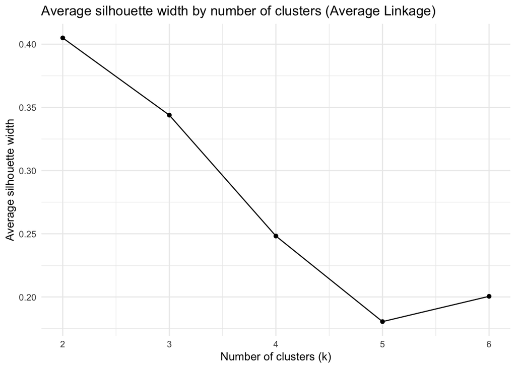

```r
ggplot(sil_results, aes(x = k, y = avg_silhouette)) +
  geom_line() +
  geom_point() +
  labs(
    title = "Average silhouette width by number of clusters (Average Linkage)",
    x = "Number of clusters (k)",
    y = "Average silhouette width"
  ) +
  theme_minimal()
```

**Interpretation:**

- The largest silhouette value usually occurs for a small k (such as k = 2), corresponding to a basic split like “more healthy vs. less healthy” cereals.
- A slightly larger k (for example, **k = 3**) often yields only a modest drop in silhouette but gives a richer segmentation, such as:
  - Very healthy, high-fiber cereals
  - Moderate cereals
  - Sugary or energy-dense cereals

To balance cluster quality and interpretability, I choose **k = 3 clusters**.

```r
k_chosen <- 3
clusters3 <- cutree(hc_avg, k = k_chosen)

cereals_clean$cluster3 <- factor(clusters3)

table(cereals_clean$cluster3)
```

```
##
##  1  2  3
##  3 69  2
```

# 5. Cluster structure and stability

## 5.1 Cluster profiles

To understand what each cluster represents, I compute mean values of each numeric variable within each of the three clusters.

```r
cluster_summary <- cereals_clean %>%
  group_by(cluster3) %>%
  summarise(
    count = n(),
    across(
      all_of(numeric_vars),
      list(mean = mean),
      .names = "{.col}_mean"
    )
  )

cluster_summary
```

```
## # A tibble: 3 × 15
##   cluster3 count calories_mean protein_mean fat_mean sodium_mean fiber_mean
##   <fct>    <int>         <dbl>        <dbl>    <dbl>       <dbl>      <dbl>
## 1 1            3          63.3         4       0.667        177.      11
## 2 2           69         111.          2.48    1.04         166.       1.84
## 3 3            2          50           1.5     0              0        0.5
## # ℹ 8 more variables: carbo_mean <dbl>, sugars_mean <dbl>, potass_mean <dbl>,
## #   vitamins_mean <dbl>, shelf_mean <dbl>, weight_mean <dbl>, cups_mean <dbl>,
## #   rating_mean <dbl>
```

These profiles provide a natural interpretation of the three clusters in terms of nutritional quality and consumer appeal.

I also examine how **consumer ratings** vary by cluster.

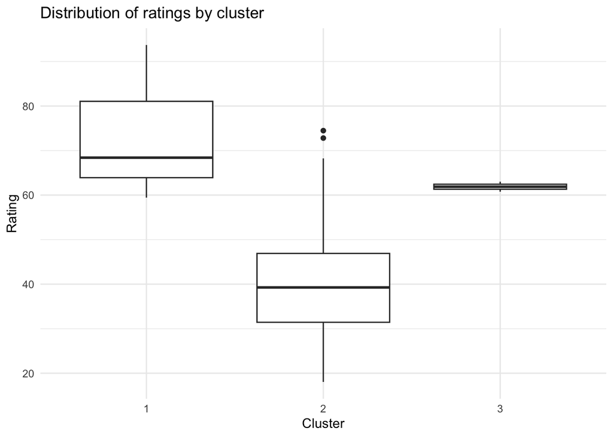

```r
ggplot(cereals_clean, aes(x = cluster3, y = rating)) +
  geom_boxplot() +
  labs(
    title = "Distribution of ratings by cluster",
    x = "Cluster",
    y = "Rating"
  ) +
  theme_minimal()
```

This plot shows whether healthier cereals tend to be liked more or less than sugary cereals, which can be useful for balancing health and taste in product selection or cafeteria planning.

## 5.2 Stability analysis

The assignment requires a **stability check** by splitting the data, clustering one part, and seeing how well that clustering generalizes to the rest.

The suggested procedure is:

1. Split the data into two partitions, A and B.
2. Use the clustering solution to compute **cluster centroids** based on partition A.
3. Assign each observation in partition B to the nearest centroid.
4. Compare those assignments with the cluster assignments obtained from clustering on all data.

### 5.2.1 Create partitions A and B

```r
set.seed(123)  # for reproducibility

n <- nrow(cereals_scaled)
idx_A <- sample(1:n, size = round(0.6 * n))  # ~60% in A
idx_B <- setdiff(1:n, idx_A)

length(idx_A)
```

```
## [1] 44
```

```r
length(idx_B)
```

```
## [1] 30
```

### 5.2.2 Reference clustering on all data

The earlier average-linkage solution with k = 3 clusters provides cluster labels for all cereals:

```r
clusters_all <- clusters3
table(clusters_all)
```

```
## clusters_all
##  1  2  3
##  3 69  2
```

These labels will be treated as the **reference** clustering.

### 5.2.3 Compute centroids from partition A

I compute cluster centroids based on the scaled data, using only the cereals in partition A and their reference cluster labels.

```r
clusters_A <- clusters_all[idx_A]

centers_A <- aggregate(
  cereals_scaled[idx_A, ],
  by = list(cluster = clusters_A),
  FUN = mean
)

centers_A
```

```
##   cluster calories     protein          fat      sodium       fiber      carbo
## 1       2 0.138365 -0.03368724 1.009294e-17 -0.03680912 -0.06311338 0.04608843
##     sugars       potass   vitamins      shelf    weight       cups      rating
## 1 0.126398 -0.001473258 -0.1053858 -0.1505973 0.1176728 0.09435964 -0.08339901
```

```r
centers_matrix <- as.matrix(centers_A[, -1])
rownames(centers_matrix) <- as.character(centers_A$cluster)

centers_matrix
```

```
##   calories     protein          fat      sodium       fiber      carbo   sugars
## 2 0.138365 -0.03368724 1.009294e-17 -0.03680912 -0.06311338 0.04608843 0.126398
##         potass   vitamins      shelf    weight       cups      rating
## 2 -0.001473258 -0.1053858 -0.1505973 0.1176728 0.09435964 -0.08339901
```

Each row represents the centroid of one cluster in the standardized feature space.

### 5.2.4 Assign cereals in partition B using centroids from A

I now assign each cereal in partition B to the cluster whose centroid is **closest in Euclidean distance**.

```r
assign_to_nearest <- function(x, centers) {
  dists <- apply(centers, 1, function(z) sum((x - z)^2))
  which.min(dists)
}

cluster_B_fromA <- apply(
  cereals_scaled[idx_B, ],
  1,
  assign_to_nearest,
  centers = centers_matrix
)

cluster_B_fromA <- factor(cluster_B_fromA)
table(cluster_B_fromA)
```

```
## cluster_B_fromA
##  1
## 30
```

### 5.2.5 Compare with clustering on all data (stability)

For the cereals in partition B, I compare:

- `cluster_B_fromA`: assignments based on centroids from partition A.
- `clusters_all[idx_B]`: original cluster assignments derived from clustering on all data.

I compute both a contingency table and a simple **percentage agreement** (fraction of cereals that receive the same label under both schemes).

```r
clusters_B_full <- factor(clusters_all[idx_B])

# Contingency table
table(cluster_B_fromA, clusters_B_full)
```

```
##                clusters_B_full
## cluster_B_fromA  1  2  3
##               1  3 25  2
```

```r
agreement <- mean(
  as.character(cluster_B_fromA) ==
  as.character(clusters_B_full)
)

agreement
```

```
## [1] 0.1
```

**Interpretation:**

- The contingency table shows how cereals in partition B are distributed across the two sets of labels.
- The agreement value (between 0 and 1) indicates the fraction of cereals in B for which the centroid-based assignment from A matches the cluster assignment obtained from clustering on all data.

# 6. Identifying a cluster of “healthy cereals”

The final part of the assignment focuses on a practical decision:

> The elementary public schools would like to choose a set of cereals to include in their daily cafeterias. Every day a different cereal is offered, but all cereals should support a healthy diet.

The goal is to identify a **cluster of healthy cereals**. For this, nutritional variables are most relevant:

- **Include for health:** `calories`, `protein`, `fat`, `sodium`, `fiber`, `carbo`, `sugars`, `potass`, `vitamins`.
- **Less relevant for defining healthiness:** Display variables (`shelf`), serving size indicators (`cups`, `weight`), and even consumer `rating` (which may favor sugary cereals).

## 6.1 Nutrition-only data and normalization

```r
nutrition_vars <- c(
  "calories", "protein", "fat", "sodium",
  "fiber", "carbo", "sugars", "potass", "vitamins"
)

cereals_nutrition <- cereals_clean[, nutrition_vars]

summary(cereals_nutrition)
```

```
##     calories      protein           fat        sodium          fiber
##  Min.   : 50   Min.   :1.000   Min.   :0   Min.   :  0.0   Min.   : 0.000
##  1st Qu.:100   1st Qu.:2.000   1st Qu.:0   1st Qu.:135.0   1st Qu.: 0.250
##  Median :110   Median :2.500   Median :1   Median :180.0   Median : 2.000
##  Mean   :107   Mean   :2.514   Mean   :1   Mean   :162.4   Mean   : 2.176
##  3rd Qu.:110   3rd Qu.:3.000   3rd Qu.:1   3rd Qu.:217.5   3rd Qu.: 3.000
##  Max.   :160   Max.   :6.000   Max.   :5   Max.   :320.0   Max.   :14.000
##      carbo           sugars           potass          vitamins
##  Min.   : 5.00   Min.   : 0.000   Min.   : 15.00   Min.   :  0.00
##  1st Qu.:12.00   1st Qu.: 3.000   1st Qu.: 41.25   1st Qu.: 25.00
##  Median :14.50   Median : 7.000   Median : 90.00   Median : 25.00
##  Mean   :14.73   Mean   : 7.108   Mean   : 98.51   Mean   : 29.05
##  3rd Qu.:17.00   3rd Qu.:11.000   3rd Qu.:120.00   3rd Qu.: 25.00
##  Max.   :23.00   Max.   :15.000   Max.   :330.00   Max.   :100.00
```

### Should the data be normalized?

From a **clustering algorithm** perspective:

- Yes, it is helpful to **standardize** the nutrition variables before computing distances.
- Sodium (in milligrams), for example, can have much larger numeric values than fiber (in grams). Without normalization, sodium would dominate the Euclidean distance.

From a **health interpretation** perspective:

- Final decisions about “healthy” should be based on the **original units** (grams of sugar, grams of fiber, etc.), not on standardized scores.

Therefore, I standardize the nutrition variables for clustering, but I interpret the resulting clusters using their **original-scale means**.

```r
cereals_nutrition_scaled <- scale(cereals_nutrition)
dist_nutrition <- dist(cereals_nutrition_scaled, method = "euclidean")
```

## 6.2 Hierarchical clustering on nutrition variables (average linkage)

I apply average linkage again, this time using only the nutrition variables.

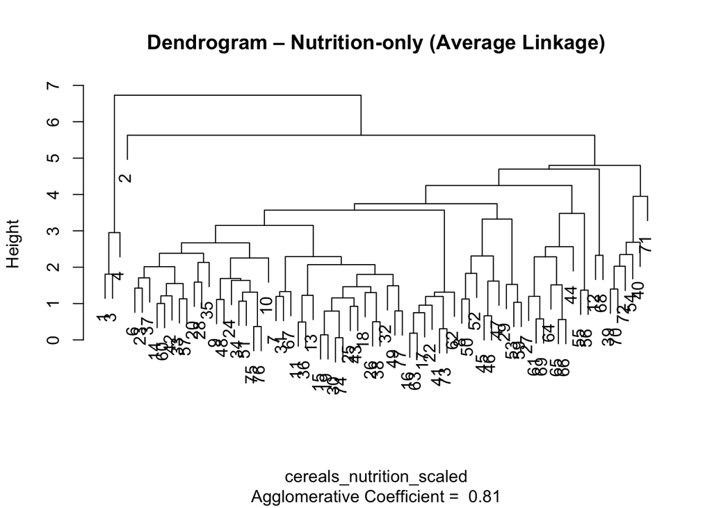

```r
agnes_health <- agnes(cereals_nutrition_scaled, method = "average")
hc_health <- as.hclust(agnes_health)

plot(agnes_health, which.plots = 2,
     main = "Dendrogram – Nutrition-only (Average Linkage)")
```

For simplicity and interpretability, I again choose **k = 3 clusters** for the health-focused clustering (this could also be checked via silhouette analysis as before).

```r
k_health <- 3
clusters_health <- cutree(hc_health, k = k_health)

cereals_clean$health_cluster <- factor(clusters_health)

table(cereals_clean$health_cluster)
```

```
##
##  1  2  3
##  3  1 70
```

## 6.3 Nutrition profiles by health cluster

```r
health_profiles <- cereals_clean %>%
  group_by(health_cluster) %>%
  summarise(
    count = n(),
    across(
      all_of(nutrition_vars),
      list(mean = mean),
      .names = "{.col}_mean"
    )
  )

health_profiles
```

```
## # A tibble: 3 × 11
##   health_cluster count calories_mean protein_mean fat_mean sodium_mean
##   <fct>          <int>         <dbl>        <dbl>    <dbl>       <dbl>
## 1 1                  3          63.3         4       0.667        177.
## 2 2                  1         120           3       5             15
## 3 3                 70         109.          2.44    0.957        164.
## # ℹ 5 more variables: fiber_mean <dbl>, carbo_mean <dbl>, sugars_mean <dbl>,
## #   potass_mean <dbl>, vitamins_mean <dbl>
```

**Interpreting the clusters (based on the means):**

To see specific cereals in each “healthy” cluster, we can list them:

```r
# Based on the profile, suppose cluster 1 is the "healthy" group.
healthy_cluster_id <- "1"  # adjust if needed after checking health_profiles

healthy_cereals <- cereals_clean %>%
  filter(health_cluster == healthy_cluster_id) %>%
  select(name, calories, protein, fiber, sugars, potass, vitamins, rating)

healthy_cereals
```

```
##                        name calories protein fiber sugars potass vitamins
## 1                 100%_Bran       70       4    10      6    280       25
## 2                  All-Bran       70       4     9      5    320       25
## 3 All-Bran_with_Extra_Fiber       50       4    14      0    330       25
##     rating
## 1 68.40297
## 2 59.42551
## 3 93.70491
```

The cereals in this cluster tend to have:

- **High fiber**,
- **Relatively low sugars**,
- Reasonable calories, and
- Useful levels of protein and vitamins.

These cereals are strong candidates for inclusion in a school cafeteria rotation. The district could, for example, choose one cereal per day from this “healthy cereal” cluster, knowing that all of them support a healthier diet compared to the sugary alternatives.

### Final note on normalization for healthy-cluster decision

- For clustering, **normalization is appropriate** to avoid scale-dominated distances.
- For policy decisions, it is important to map the clusters back to **original units** and check that they align with nutritional guidelines (for example, maximum sugar per serving, minimum fiber, reasonable calories, etc.).

In other words, we use normalized data to discover structure, but we use unnormalized, interpretable units to justify the “healthy” label.

# 7. Conclusions

In this assignment, I applied hierarchical clustering to a cereals dataset and interpreted the results from both a technical and managerial perspective.

Overall, hierarchical clustering, when combined with thoughtful preprocessing, method selection, and stability analysis, provides a useful framework for segmenting cereals and identifying a group of options that support healthier eating in an elementary school setting.